# Predicting Customer Response in Bank Marketing Campaign for Term Deposit Subscription

Nigar Sultana

# 1 Introduction

Direct marketing campaigns have become an increasingly important strategy for businesses looking to engage customers and drive revenue growth. However, achieving success with these campaigns requires a deep understanding of customer behavior, preferences, and demographics. Data analysis plays a critical role in this process, providing businesses with the insights needed to develop targeted and tailored marketing strategies. In the banking industry, direct marketing campaigns are especially critical, as they can have a significant impact on customer acquisition and retention. By analyzing customer data, businesses can gain valuable insights into which marketing tactics are most effective, which customer segments are most likely to respond positively to marketing efforts, and which factors influence the decision to subscribe to a term deposit.

This project aim to build a predictive model that can be used to optimize marketing campaign in the banking industry. The direct bank marketing data in the UCI machine learning repository has been utilized to build classification algorithm to predict whether or not a customer is likely to subscribe to a term deposit based on their characteristics and the details of the marketing campaign.

# 2 Data

The direct bank marketing data in the UCI machine learning repository contains information about a direct marketing campaign of a Portuguese banking institution. The goal of the campaign was to promote a term deposit among the bank’s customers.

The data set was collected through phone calls made to customers between May 2008 and November 2010. The phone calls were made by the bank’s marketing team, and the customers were selected randomly from a database of the bank’s clients. The phone calls were made using a standard script that provided information about the term deposit and asked the customer if they would be interested in subscribing to it.

The data set includes 41,188 instances, each representing a contact made with a customer during the campaign. For each contact, there are 21 input variables (such as age, job, education, marital status, etc.) and one binary output variable, which indicates whether or not the customer subscribed to the term deposit. Each phone call in the data set is a row, while the columns correspond to the variables whose names and definitions are the following:

| variable | description |
| --- | --- |
| age | numeric |
| job | type of job (categorical): “admin.”,“blue-collar”,“entrepreneur”,“housemaid”,“management”,“retired”,“self-employed”,“services”,“student”,“technician”,“unemployed”,“unknown”) |
| marital | marital status (categorical: “divorced”,“married”,“single”,“unknown”; note: “divorced” means divorced or widowed) |
| education | categorical: “basic.4y”,“basic.6y”,“basic.9y”,“high.school”,“illiterate”,“professional.course”,“university.degree”,“unknown” |
| default | has credit in default? (categorical: “no”,“yes”,“unknown”) |
| housing | has housing loan? (categorical: “no”,“yes”,“unknown”) |
| loan | has personal loan? (categorical: “no”,“yes”,“unknown”) |
| contact | contact communication type (categorical: “cellular”,“telephone”) |
| month | last contact month of year (categorical: “jan”, “feb”, “mar”, …, “nov”, “dec”) |
| day_of_week | last contact day of the week (categorical: “mon”,“tue”,“wed”,“thu”,“fri”) |
| duration | last contact duration, in seconds (numeric). Important note: this attribute highly affects the output target (e.g., if duration=0 then y=“no”). Yet, the duration is not known before a call is performe… |
| campaign | number of contacts performed during this campaign and for this client (numeric, includes last contact) |
| pdays | number of days that passed by after the client was last contacted from a previous campaign (numeric; 999 means client was not previously contacted) |
| previous | number of contacts performed before this campaign and for this client (numeric) |
| poutcome | outcome of the previous marketing campaign (categorical: “failure”,“nonexistent”,“success”) |
| emp.var.rate | employment variation rate - quarterly indicator (numeric) |
| cons.price.idx | consumer price index - monthly indicator (numeric) |
| cons.conf.idx | consumer confidence index - monthly indicator (numeric) |
| euribor3m | euribor 3 month rate - daily indicator (numeric) |
| nr.employed | number of employees - quarterly indicator (numeric) |
| y | has the client subscribed a term deposit? (binary: “yes”,“no”) |

# 3 Exploratory Data Analysis

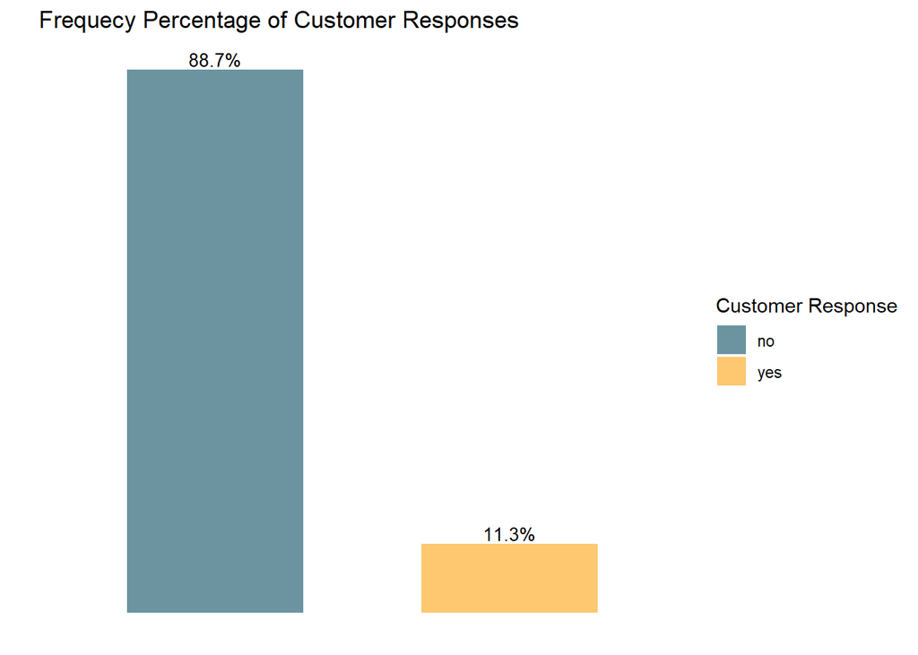

From all the customers those had been contacted, only 11.3% of them subscribed to the term deposit.

## 3.1 Customers’ Demography

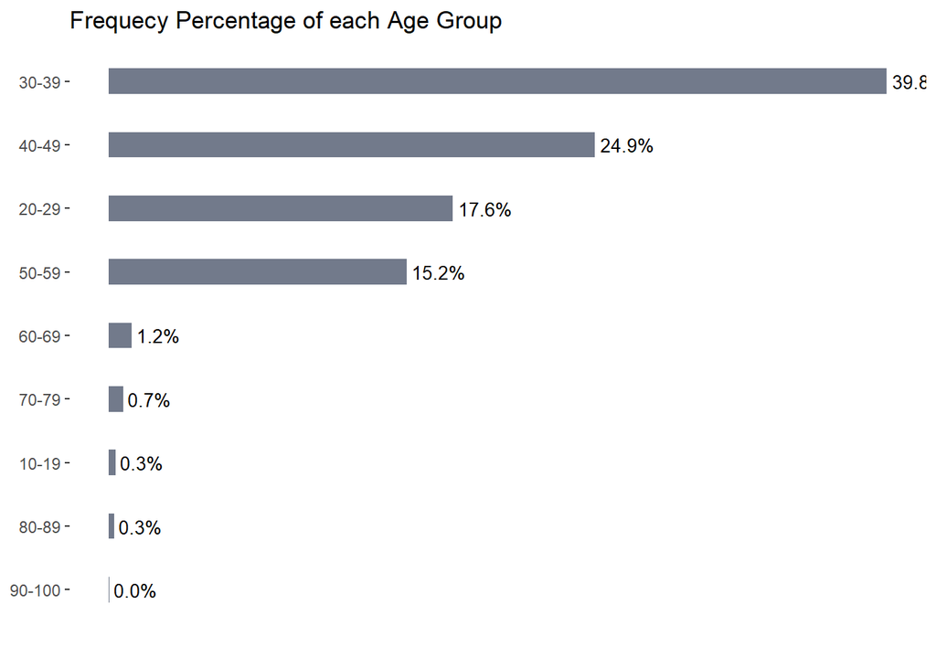

People who fall between 30-39 age group have mostly been contacted by the bank followed by the age group between 40-49.

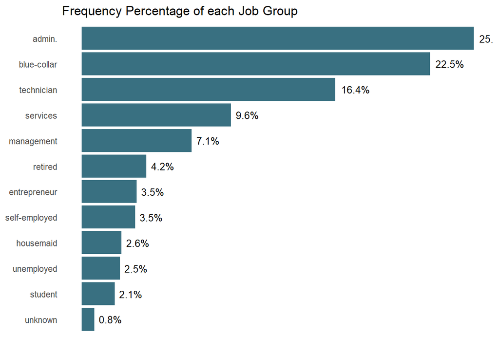

The marketing campaign primarily targeted individuals in the “admin” job group, with the “blue-collar” job group being the second most contacted. On the other hand, the “student” group received the least amount of contact from the marketing team. This indicates that the marketing strategy focused on reaching out to professionals in administrative roles and those working in manual or labor-intensive jobs, while giving less priority to students.

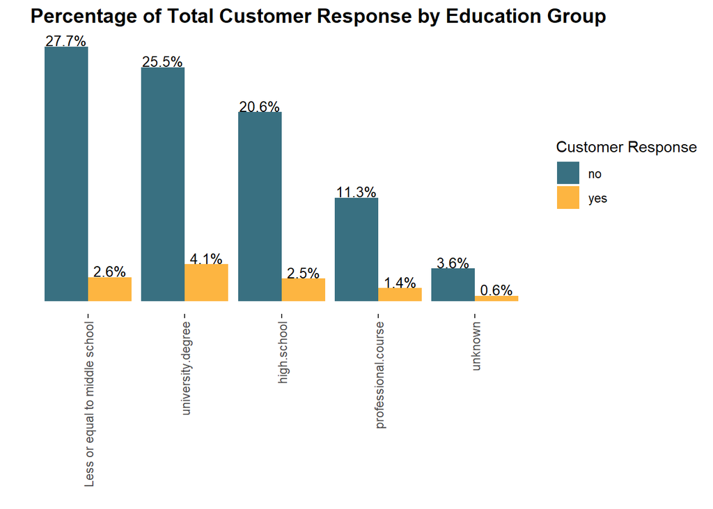

The customers with middle school education or less were highest in numbers in the direct-marketing campaign, followed by the customers with university degree. Among the targeted customers, customers with a university degree demonstrated a higher likelihood of subscribing to the term deposit compared to other education groups.